# Monte Carlo Set 1

## Karl Jiang

### 1.13)

The function (routine) to generate the sample averages and plot is below.

```python
import numpy as np
import matplotlib.pyplot as plt
import matplotlib.mlab as mlab

def clt_exp(n, ns = 5000):
    '''
    Generates ns sample averages (x_bars) for sample size n. Plots
    histogram of the normalized x_bars (z_bars).

    Params:
        n: the sample size
        ns: number of samples
    '''
    x_bars = []
    for i in range(ns):
        xs = np.random.exponential(size = n)
        x_bars.append( np.mean(xs) )
    x_bars = np.array(x_bars)

    pi_x = 1 #expected value exp(1)
    sigma = 1 #sd of exp(1)
    z_bars =  np.sqrt(n) * ( x_bars - pi_x )

    #plot
    #k, bins, patches = plt.hist(z_bars, normed = True)
    #y = mlab.normpdf(bins, pi_x, sigma)
    #l = plt.plot(bins, y, 'r--', linewidth = 1)
    plt.hist(z_bars, normed = True)
    plt.xlabel('x_bar')
    plt.ylabel('Probabillity')
    plt.title('CLT histogram, exp(1), n = {}'.format(n))
    plt.grid(True)

    plt.show()
    #return z_bars
```

We will show that the histogram tends towards a normal distribution for increasing n. (For 5000 sample averages)

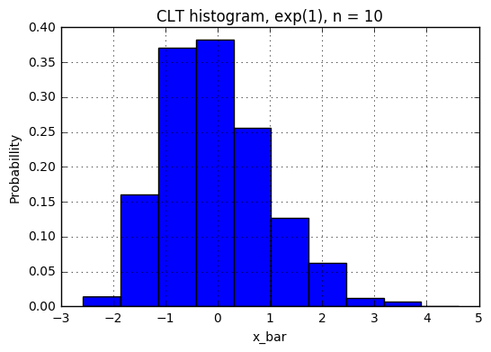

```python
clt_exp(10)
```

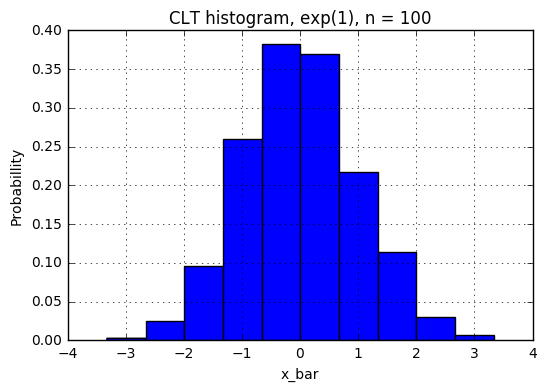

```python
clt_exp(100)
```

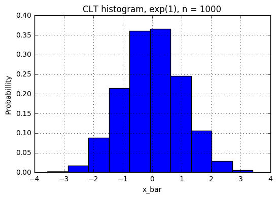

```python
clt_exp(1000)
```

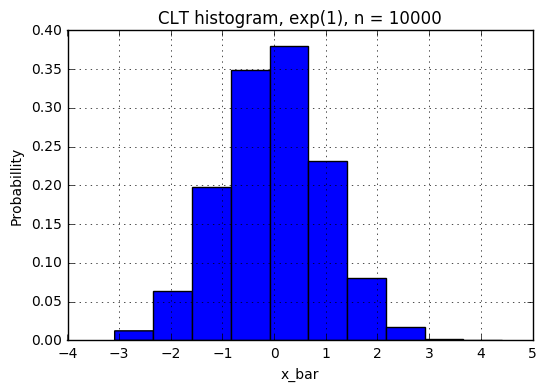

```python
clt_exp(10000)
```

As the sampe size increases, the histogram approaches the normal distribution density.

#### Decay Rate )

Below is the routine to classify the event $Q_n = \bar{x}_n - \pi x > 0.1$:

```python
def exp_one_deviations(n, epsilon = 0.1):
    '''
    generates a sample mean (of exp(1) rv's) with sample size n. Returns True if event is satsified
    Params:
        n - int, number of samples to generate
        epsilon - the deviation
    Returns:
        True if the sample mean > epsilon, False o.w.
    '''

    mu = 1
    x_bar = np.mean( np.random.exponential(size = n) )
    diff = x_bar - mu
    if x_bar - mu > epsilon:
       # print(x_bar - mu)
        return True
    return False
```

Below is the routine to estimate $\mathbb{P}(\bar{x}_n - \pi x > 0.1)$, which basically just takes the average of a bunch of independent samples of $\bar{x}$ for the event $\bar{x}_n - \pi x > 0.1$ since we are really just finding the parameter $p$ of a bernoulli($p$)

```python
def est_prob(N, n, epsilon = 0.1):
    '''
     Params:
        N - int, the number of means to generate
        n - int, number of samples to generate (for sample mean)
        epsilon - int, the deviation
    Returns:
        Estimate of the indicator event
    '''
    rs = []
    for i in range(N):
        rs.append( exp_one_deviations(n, epsilon) )
    #print(rs)

    return np.mean(rs)
```

```python
sample_size = 1000
P = est_prob(100000, sample_size) #simple demonstration that with many samples, chance of 0.1 deviation is pretty much 0.
print(P)
```

```
0.00093
```

To estimate the value obtained from Cramer's Large Deviation principle, we simply take the log of the estimated probabillity and divide by sample size $n$. (As long as $n$ is large):

```python
est_decay = np.log(P) / sample_size

epsilon = 0.1
actual_decay = -epsilon + np.log(1 + epsilon)

print("est decay: {} \t| actual decay: {}".format(est_decay, actual_decay))
```

```
est decay: -0.00698032597182 	| actual decay: -0.00468982019568
```

#### Comparison with standard deviation

Since $Q_n$ is bernoulli $\bar{x} - \pi x > 0.1$ with probabillity $p(n) = \mathbb{P}(\bar{x}_n - \pi x > 0.1)$, where $n$ is the number of samples, then the standard deviation of $Q_n$ is $\sqrt{p(n)(1 - p(n))}$. Therefore,
$$\lim_{n\to\infty} \frac{1}{n} log(\sqrt{p(n)(1 - p(n) )} ) = $$ $$\lim_{n\to\infty} \frac{1}{2n} ( log( p(n) ) + log(1 - p(n) ) = $$ $$\lim_{n\to\infty} \frac{1}{2n} log( p(n) ) + \lim_{n\to\infty} \frac{1}{2n} log(1 - p(n) ) = $$
And by the law of large numbers, $p(n) \rightarrow 0$ as $n \rightarrow \infty$, thus $log(1 - p(n) )$ will approach $0$ and the second term vanishes. This leaves us with $$\lim_{n\to\infty} \frac{1}{2n} log( p(n) ) = \frac{1}{2} \lim_{n\to\infty} \frac{1}{n} log( p(n) ) < \lim_{n\to\infty} \frac{1}{n} log( p(n) )$$
Thus, the standard deviation of $Q_n$ has a rate of decay that is smaller than the rate of decay of $\mathbb{P}(Q_n)$. This is not ideal.

### 2.15) The root distribution

Integrating the density $\pi$, we get $F(x) = \sqrt{x}$ for $0 \leq x \leq 1$, thus $F^{-1}(x) = x^{2}$. The histogram that shows the inversion technique is shown below

```python
def sqrt_density(n):
    '''
    Samples from the 1/(2sqrt(x)) density on [0,1].
    Plots histogram of the random variables drawn from this distribution.
    Params:
        n - int, number of samples to be drawn from said density
    '''
    x = np.random.random(size = n)
    x_trans = np.power(x, 2)

    if n > 1000:
        plt.hist(x_trans, bins = 25)
    else:
        plt.hist(x_trans)
    plt.xlabel('x_transformed')
    plt.ylabel('Frequency')
    plt.title('Histogram: 1 / (2sqrt(x) ) on [0,1], {} samples'.format(n))
    plt.grid(True)
    plt.show()
```

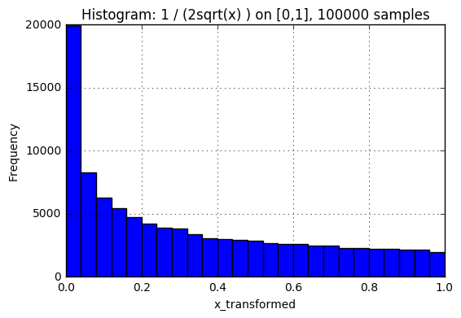

```python
sqrt_density(100000) #see how it looks like 1 / (2 sqrt(x) ) function
```

### 2.17) Mox - Muller Implementation

We implement the box muler transform below. 2D Histogram follows.

```python
def box_muller(n):
    '''
    params:
        n - int, number of gaussian pairs to be generated
    returns:
        numpy 2d array of n independently generated gaussian pairs (all independent)
    '''
    u1 = np.random.random(n)
    u2 = np.random.random(n)

    phi_1 = np.sqrt(-2 * np.log(u1) ) * np.cos(2 * np.pi * u2)
    phi_2 = np.sqrt(-2 * np.log(u1) ) * np.sin(2 * np.pi * u2)

    return np.array( [phi_1, phi_2] )
```

```python
def hist_box_muller(n):
    '''
    Generates n pairs of N(0,1) random variables, and plots 2d histogram of the pairs
    '''
    X = box_muller(n)
    if n > 1000:
        plt.hist2d(X[0], X[1], bins = 50)
    else:
        plt.hist2d(X[0], X[1])
    plt.colorbar()
    plt.show()
```

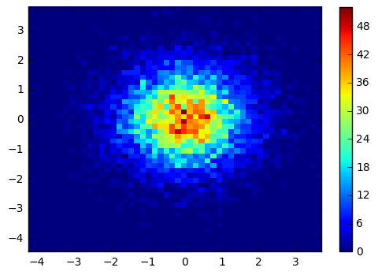

```python
hist_box_muller(10000)
```

### 2.18) Generating from the Unit Disk

```python
def r_unit_circle(n):
    '''
    Samples (x1, x2) to be uniformally distributed across the unit circle
    params:
        -n - int, number of points to generate on unit circle
    returns:
        n x 2 numpy array where each row (x,y) is a coordinate on the unit circle
    '''
    u1 = np.random.random(n)
    u2 = np.random.random(n)

    phi_1 = np.sqrt(u1) * np.cos(2 * np.pi * u2)
    phi_2 = np.sqrt(u1) * np.sin(2 * np.pi * u2)

    return np.array( [phi_1, phi_2] )
```

```python
def hist_unit_circle(n):
    '''
    Generates n pairs uniformally dist. across unit circle, and plots 2d histogram of the pairs
    '''
    X = r_unit_circle(n)
    if n > 1000:
        plt.hist2d(X[0], X[1], bins = 30)
    else:
        plt.hist2d(X[0], X[1])
    plt.colorbar()
    plt.show()
```

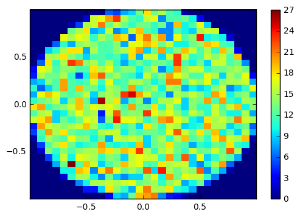

```python
hist_unit_circle(10000)
```

### 2.19) Rejection Sampling the Unit Circle

We must choose $K$ such that $K \geq 1$ and $K \geq \frac{\pi}{\widetilde{\pi}}$.  
$\pi$ is the uniform density on the unit circle, which is $\frac{1}{\pi}$ on support $0 \leq x^2 + y^2 \leq 1$  
$\widetilde{\pi}$ is the uniform density on the unit square, which is $\frac{1}{4}$ with support $-1 \leq x \leq 1$ and $-1 \leq y \leq 1$  
Therefore, the "optimal" (or smallest possible value of) $K$ would just be $\frac{4}{\pi}$  
The general rejection function (one that takes in densities $\pi$ and $\widetilde{\pi}$ is implemented below:

```python
def pi_density(x):
    #x is supposed to be a vector / array for any general density. Here its just an (x,y) cooridnate
    if np.square(x[0]) + np.square(x[1]) <= 1:
        return 1 / np.pi
    return 0

def unit_sq_density(x):
    #density of unit square
    if -1 <= x[0] <= 1 and -1 <= x[1] <= 1:
        return 0.25
    return 0

def sample_unit_square(n):
    '''
    params:
        - n: number of points to sample
    returns:
        - n x 2 array of (x,y) on unit square
    '''
    samples = []
    for i in range(n):
        samples.append( np.random.random(2) * 2 - 1 )
    return samples
```

```python
def rejection_samples(pi, pi_t, pi_t_sample, k, n):
    '''
    params:
        pi - density function that takes in a np.array of ints and maps to scalar.
            Should be the density to sample from
        pi_t - density function that takes in a np.array of ints and maps to scalar.
            Should be denisty that can already be sampled from.
        pi_t_sample - generates random variables with distribution pi_t.
        k - the constant k used in rejection sampling (for condition to not reject)
        n of samples to be drawn from distribution pi
    returns:
        dictionary with key 'X' and 'Y', each with a list value where a row corresponds to the (x,y) coordinates
    '''
    samples = {'X' : [], 'Y' : []}
    for i in range(n):
        reject = True
        while reject:
            u = np.random.random(1)[0]
            y = pi_t_sample(1)[0][:]
            v = pi(y) / ( k * pi_t(y) )
            condition_met = u <= pi(y) / ( k * pi_t(y) )
            if condition_met:
                #print("u: {}\t| v: {}".format( u, v ) )
                reject = False
                samples['X'].append(y[0])

                samples['Y'].append(y[1])
    return samples
```

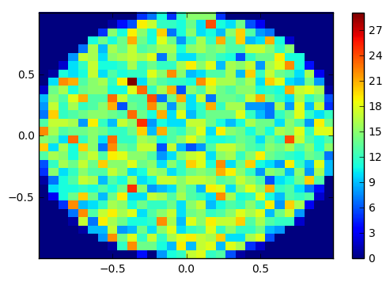

```python
n = 10000
k = 4 / np.pi
rs = rejection_samples(pi_density, unit_sq_density, sample_unit_square, k, n)
if n > 1000:
    plt.hist2d(rs['X'], rs['Y'], bins = 30)
else:
    plt.hist2d(rs['X'], rs['Y'])
plt.colorbar()
plt.show()
```

The cost of rejection sampling is about $K$ times as more as directly generating from the unit disk since $\mathbb{E}[\tau] = K$  
Eg. if we wanted to generate $n$ points on the unit circle, then directly generating points would take n iterations, whereas rejection samping would take $Kn$ iterations.